# R Exam 3

Preamble: This is Ryan Herrschaft’s final examination submission.

```r
#Add a premble
#Clean out environment
rm(list = ls())

#Session info
date()
```

```
[1] "Sun Dec 15 14:59:24 2019"
```

```r
#install.packages ("tidyverse")
#install.packages ("Hmisc")
#install.packages ("dplyr")
#install.packages("stringr")
library (tidyverse)
library (Hmisc)
library (dplyr)
library(stringr)
#for spatial data sf package if you 2want to do spatial data (bonus)


#Nola_Crime <- read_csv("C:/Users/rherrsch/Downloads/nola_crime_2018.csv")
Nola_Crime <- read_csv("/Users/ryanherrschaft/Downloads/nola_crime_2018.csv")
```

Question 1: How many observations are in the datbase? Question 2" How many variables are there? Question 3: How many unique item numbers are there in this database?

```r
#Question 1: How many observations are in the datbase?
#Question 2" How many variables are there?
# Both o these are visible in the Environment window.

#Question 3: How many unique item numbers are there in this database?


describe(Nola_Crime$Item_Number)
```

```
Nola_Crime$Item_Number
       n  missing distinct
    9970        0     9384

lowest : A-00034-19 A-00128-18 A-00168-18 A-00213-18 A-00228-18
highest: X-00038-18 X-00040-18 X-00045-18 X-00051-18 X-00056-18
```

Questions 1-3: There are 9970 observations and 24 variables. There are 9384 unique item numbers.

4.) Considering only unique item numbers as crimes, how many “aggravated” crimes occured in the Irish Channel Neighborhood?

```r
#I found a command called grepl, matches what you write in the parentheses with  a string of characters in any collumn.

Aggravated_crime_Irish <- filter(Nola_Crime, GNOCDC_LAB == "IRISH CHANNEL" & grepl('AGGRAVATED', Signal_Description))

describe(Aggravated_crime_Irish)
```

```
Aggravated_crime_Irish

 24  Variables      1  Observations
-----------------------------------------------------------------------------------------------------
Item_Number
         n    missing   distinct      value
         1          0          1 B-15298-18

Value      B-15298-18
Frequency           1
Proportion          1
-----------------------------------------------------------------------------------------------------
District
       n  missing distinct     Info     Mean      Gmd
       1        0        1        0        8       NA

Value      8
Frequency  1
Proportion 1
-----------------------------------------------------------------------------------------------------
Location
                               n                          missing                         distinct
                               1                                0                                1
                           value
Tchoupitoulas St & Notre Dame St

Value      Tchoupitoulas St & Notre Dame St
Frequency                                 1
Proportion                                1
-----------------------------------------------------------------------------------------------------
Disposition
       n  missing distinct    value
       1        0        1     OPEN

Value      OPEN
Frequency     1
Proportion    1
-----------------------------------------------------------------------------------------------------
Signal_Type
       n  missing distinct    value
```

[output cut: 139 more lines]

```
Frequency              1
Proportion             1
-----------------------------------------------------------------------------------------------------
pop
       n  missing distinct     Info     Mean      Gmd
       1        0        1        0    12852       NA

Value      12852
Frequency      1
Proportion     1
-----------------------------------------------------------------------------------------------------

Variables with all observations missing:

[1] Offender_Age Hate_Crime
```

```r
describe(Aggravated_crime_Irish$Item_Number)
```

```
Aggravated_crime_Irish$Item_Number
         n    missing   distinct      value
         1          0          1 B-15298-18

Value      B-15298-18
Frequency           1
Proportion          1
```

There was 1 unique identifiers for an aggravated crime occuring in the Irish Channel.

5. What two neighborhoods have the largest numbers of crime reports (unique items)?

```r
Crimes_Distinct <- Nola_Crime %>% group_by(GNOCDC_LAB) %>%  summarise (item_numbers = n_distinct(Item_Number, na_rm= FALSE)) %>% arrange(desc(item_numbers))

head(Crimes_Distinct)
```

| GNOCDC_LAB | item_numbers |
| --- | --- |
| FRENCH QUARTER | 670 |
| LITTLE WOODS | 595 |
| CENTRAL BUSINESS DISTRICT | 551 |
| CENTRAL CITY | 540 |
| SEVENTH WARD | 401 |
| NA | 393 |

The French Quarter and Little Woods have the largest number of unique crime reports.

6. (10 points) Assume that the each person in the population contributes exactly one year of time at risk, calculate the rate of crime (unique items) per 1,000 persons in each neighborhood in the dataset for 2018, show this in a table in your report?

```r
#This is the same variable item variable as above, I am adding in population and then creating the rate

Crime_Rate_by_district <- Nola_Crime %>% group_by(GNOCDC_LAB) %>%  summarise (item_numbers = n_distinct(Item_Number, na_rm= FALSE), pop=mean(pop, na_rm=FALSE)) %>% mutate(Rate_of_Crime_per_1000=((item_numbers/pop)*1000))

head(Crime_Rate_by_district)
```

| GNOCDC_LAB | item_numbers | pop | Rate_of_Crime_per_1000 |
| --- | --- | --- | --- |
| ALGIERS POINT | 26 | 12848 | 2.023661 |
| AUDUBON | 103 | 37946 | 2.714384 |
| B. W. COOPER | 26 | 7821 | 3.324383 |
| BAYOU ST. JOHN | 45 | 19352 | 2.325341 |
| BEHRMAN | 232 | 25562 | 9.075972 |
| BLACK PEARL | 11 | 6569 | 1.674532 |

```r
NA
NA
NA
NA
```

7. (15 points) What is the largest neighborhood by population in the dataset and what is its total population?

```r
#I am just using the same code as last time, but I am going to arragne by population

Crime_Rate_by_district <- Nola_Crime %>% group_by(GNOCDC_LAB) %>%  summarise (item_numbers = n_distinct(Item_Number, na_rm= FALSE), pop=mean(pop)) %>% mutate(Rate_of_Crime_per_1000=((item_numbers/pop)*1000)) %>% arrange(desc(pop))

head(Crime_Rate_by_district)
```

| GNOCDC_LAB | item_numbers | pop | Rate_of_Crime_per_1000 |
| --- | --- | --- | --- |
| LITTLE WOODS | 595 | 44947 | 13.237813 |
| OLD AURORA | 205 | 40130 | 5.108398 |
| AUDUBON | 103 | 37946 | 2.714384 |
| CENTRAL CITY | 540 | 35385 | 15.260704 |
| TALL TIMBERS - BRECHTEL | 217 | 35314 | 6.144872 |
| ST. ROCH | 291 | 32067 | 9.074750 |

```r
NA
NA
```

The largest neighborhood by population is Little Woods, with a population of 44,947.

8. (10 points) What is the population size and number of unique crimes in the neighborhood with the lowest rate of crime (unique items) per 1,000 person years?

```r
#This is the same code as before, only I am changing the arrange to be by the Rate of Crime in ascending order

Q_8_Crime_Rate_by_district <- Nola_Crime %>% group_by(GNOCDC_LAB) %>%  summarise (item_numbers = n_distinct(Item_Number, na_rm= FALSE), pop=mean(pop)) %>% mutate(Rate_of_Crime_per_1000=((item_numbers/pop)*1000)) %>% arrange(Rate_of_Crime_per_1000)

head(Q_8_Crime_Rate_by_district)
```

| GNOCDC_LAB | item_numbers | pop | Rate_of_Crime_per_1000 |
| --- | --- | --- | --- |
| LAKEWOOD | 10 | 13989 | 0.7148474 |
| PONTCHARTRAIN PARK | 17 | 18380 | 0.9249184 |
| LAKESHORE - LAKE VISTA | 15 | 12956 | 1.1577647 |
| FLORIDA DEV | 6 | 4976 | 1.2057878 |
| EAST CARROLLTON | 22 | 17782 | 1.2372062 |
| CITY PARK | 30 | 24140 | 1.2427506 |

Lakewood has the lowest rate of crime. There were 10 incidents of crime and the area has a population of 13,989.

9. (10 points) Calculate the rate ratio for each neighborhood for all unique crimes treating LAKE WOOD as the reference (denominator)?

```r
#I am first going to assign the Lakewood observation to an object.
# I will then use the mutate command to produce a new variable called rate ratio

#The rate of crime in Lakewood was .7148474

Q_9_Crime_Rate_by_district <- Nola_Crime %>% group_by(GNOCDC_LAB) %>%  summarise (item_numbers = n_distinct(Item_Number, na_rm= FALSE), pop=mean(pop)) %>% mutate(Rate_of_Crime_per_1000=((item_numbers/pop)*1000)) %>% mutate(Rate_Ratio_Lakewood = ((Rate_of_Crime_per_1000/.7148474)))

head(Q_9_Crime_Rate_by_district)
```

| GNOCDC_LAB | item_numbers | pop | Rate_of_Crime_per_1000 | Rate_Ratio_Lakewood |
| --- | --- | --- | --- | --- |
| ALGIERS POINT | 26 | 12848 | 2.023661 | 2.830900 |
| AUDUBON | 103 | 37946 | 2.714384 | 3.797151 |
| B. W. COOPER | 26 | 7821 | 3.324383 | 4.650479 |
| BAYOU ST. JOHN | 45 | 19352 | 2.325341 | 3.252920 |
| BEHRMAN | 232 | 25562 | 9.075972 | 12.696377 |
| BLACK PEARL | 11 | 6569 | 1.674532 | 2.342503 |

```r
NA
```

10.)Calculate the rate ratio for each neighborhood for all unique “aggravated crimes” treating FRENCH QUARTER as the reference (denominator)?

```r
#First I am going to find out the rate of aggravateed crimes for all districts. I am going to arrange them in decreasing order of rate of crime.

Aggravated_crime <- Nola_Crime %>% filter(grepl('AGGRAVATED', Signal_Description)) %>% group_by(GNOCDC_LAB) %>%  summarise (item_numbers = n_distinct(Item_Number, na_rm= FALSE), pop=mean(pop)) %>% mutate(Rate_of_Crime_per_1000=((item_numbers/pop)*1000)) %>% arrange(desc(Rate_of_Crime_per_1000))

head(Aggravated_crime)
```

| GNOCDC_LAB | item_numbers | pop | Rate_of_Crime_per_1000 |
| --- | --- | --- | --- |
| FRENCH QUARTER | 15 | 15172 | 0.9886633 |
| SEVENTH WARD | 23 | 23878 | 0.9632298 |
| LITTLE WOODS | 37 | 44947 | 0.8231918 |
| ST. CLAUDE | 15 | 18616 | 0.8057585 |
| PLUM ORCHARD | 11 | 14671 | 0.7497785 |
| HOLLYGROVE | 8 | 11723 | 0.6824192 |

```r
#With this, I see that the French Quarter has the highest crime rate, .98866333. I then take this value as the denominator for the variable Rate_Ratio_FQ

#Note: It seems that some districts had no aggravated crimes and were dropped from sample. This leaves me with 57 observations, rather than 73.

#The below statement gives me the table I want.

Q_10_Rate_Aggravated_crime <- Nola_Crime %>% filter(grepl('AGGRAVATED', Signal_Description)) %>% group_by(GNOCDC_LAB) %>%  summarise (item_numbers = n_distinct(Item_Number, na_rm= FALSE), pop=mean(pop)) %>% mutate(Rate_of_Crime_per_1000=((item_numbers/pop)*1000)) %>% mutate(Rate_Ratio_FQ = ((Rate_of_Crime_per_1000/.98866333)))

head(Q_10_Rate_Aggravated_crime)
```

| GNOCDC_LAB | item_numbers | pop | Rate_of_Crime_per_1000 | Rate_Ratio_FQ |
| --- | --- | --- | --- | --- |
| BAYOU ST. JOHN | 1 | 19352 | 0.05167425 | 0.05226678 |
| BEHRMAN | 11 | 25562 | 0.43032627 | 0.43526067 |
| BROADMOOR | 5 | 15376 | 0.32518210 | 0.32891086 |
| BYWATER | 6 | 25185 | 0.23823705 | 0.24096883 |
| CENTRAL BUSINESS DISTRICT | 10 | 18764 | 0.53293541 | 0.53904640 |
| CENTRAL CITY | 13 | 35385 | 0.36738731 | 0.37160002 |

11.) What is the most common cause for a police report to be filed (captured in the “signal description” variable) and what is the most common charge that is filed?

```r
Reports<- Nola_Crime %>%  group_by(Signal_Description) %>% summarise (item_numbers = n_distinct(Item_Number, na_rm= FALSE))  %>% arrange(desc(item_numbers))

head(Reports)
```

| Signal_Description | item_numbers |
| --- | --- |
| DISTURBANCE (DOMESTIC) | 1521 |
| MISCELLANEOUS INCIDENT | 855 |
| DRUG LAW VIOLATION | 522 |
| SIMPLE BURGLARY (VEHICLE) | 506 |
| SIMPLE BATTERY (DOMESTIC) | 482 |
| SHOPLIFTING | 474 |

```r
#The most common cause for a police report is Domestic Disturbance.

Charges <- Nola_Crime %>% group_by(Charge_Code) %>%  summarise (item_numbers = n_distinct(Item_Number, na_rm= FALSE))  %>% arrange(desc(item_numbers))

head(Charges)
```

| Charge_Code | item_numbers |
| --- | --- |
| NA | 5151 |
| 14 67 | 602 |
| 14 62 | 425 |
| 14 56 | 355 |
| FUGITIVE ATTACHMENT | 264 |
| 14 35.3 | 200 |

```r
  #I see that the Charge_Code 14 67 is the most commonly filed code.
```

12.)Calculate the rate of domestic disturbance (again based on “signal descrip- tion”) by neighborhood and show this as a table in your report.

```r
dom_disturb <- Nola_Crime %>%  filter(str_detect(Signal_Description,"DOMESTIC")) %>% filter(str_detect(Signal_Description, "DISTURBANCE")) %>% group_by(GNOCDC_LAB) %>% summarise (item_numbers = n_distinct(Item_Number, na_rm= FALSE), pop=mean(pop)) %>% mutate(Rate_of_Crime_per_1000=((item_numbers/pop)*1000))

head(dom_disturb)
```

| GNOCDC_LAB | item_numbers | pop | Rate_of_Crime_per_1000 |
| --- | --- | --- | --- |
| ALGIERS POINT | 5 | 12848 | 0.3891656 |
| AUDUBON | 4 | 37946 | 0.1054130 |
| B. W. COOPER | 4 | 7821 | 0.5114435 |
| BAYOU ST. JOHN | 7 | 19352 | 0.3617197 |
| BEHRMAN | 48 | 25562 | 1.8777873 |
| BLACK PEARL | 2 | 6569 | 0.3044603 |

```r
NA
NA
```

13.) Fit a linear regression model to a summary dataset that you create which contains the rate of all crimes calculated by neighborhood as in previous calculation and includes the average age of the victims in that neighborhood as a predictor, include the summary of the regression results in your report by using the summary() function.

```r
#I had trouble creating a code that would have all of the infomraiton I need appear in one table. So, I just created two different tables and then merged them.

Crime_Rate_13 <- Nola_Crime %>% group_by(GNOCDC_LAB) %>%  summarise (item_numbers = n_distinct(Item_Number, na_rm= TRUE), pop=mean(pop)) %>%  mutate(Rate_of_Crime_per_1000=((item_numbers/pop)*1000))

Mean_age_avg<- aggregate(Victim_Age ~ GNOCDC_LAB, Nola_Crime, mean)

data_for_lm<-merge(Crime_Rate_13, Mean_age_avg)
head(data_for_lm)
```

|  | GNOCDC_LAB | item_numbers | pop | Rate_of_Crime_per_1000 | Victim_Age |
| --- | --- | --- | --- | --- | --- |
| 1 | ALGIERS POINT | 26 | 12848 | 2.023661 | 42.12000 |
| 2 | AUDUBON | 103 | 37946 | 2.714384 | 39.07246 |
| 3 | B. W. COOPER | 26 | 7821 | 3.324383 | 37.63636 |
| 4 | BAYOU ST. JOHN | 45 | 19352 | 2.325341 | 42.10526 |
| 5 | BEHRMAN | 232 | 25562 | 9.075972 | 38.13812 |
| 6 | BLACK PEARL | 11 | 6569 | 1.674532 | 38.12500 |

```r
lm_item_age<-glm(item_numbers~Victim_Age, data=data_for_lm)
summary(lm_item_age)
```

```
Call:
glm(formula = item_numbers ~ Victim_Age, data = data_for_lm)

Deviance Residuals:
    Min       1Q   Median       3Q      Max
-163.17   -76.64   -40.13    26.71   530.84

Coefficients:
            Estimate Std. Error t value Pr(>|t|)
(Intercept)  377.672    175.600   2.151    0.035 *
Victim_Age    -6.361      4.399  -1.446    0.153
---
Signif. codes:  0 ‘***’ 0.001 ‘**’ 0.01 ‘*’ 0.05 ‘.’ 0.1 ‘ ’ 1

(Dispersion parameter for gaussian family taken to be 19493.04)

    Null deviance: 1405265  on 71  degrees of freedom
Residual deviance: 1364513  on 70  degrees of freedom
AIC: 919.5

Number of Fisher Scoring iterations: 2
```

14.) Assume that high numbers of police reports happen in places with adequate police responsiveness but that true rates of criminal acts are similar everywhere. If this is true than the absolute numbers of crimes depend only on population size but the number of reports depends on both population size and crime rates. If these hypothesis are true, which neighborhood might have the worst police responsiveness (i.e. Low rates of crime reporting - i.e. low numbers of signals/reports and high population)?

```r
#This question asks us to interpret the crime rate in a different way than we originaly did. Now, we are interpreting it such that low rates of crime with high populations suggest not less crime.

#The prompt asks us to assume that number of crimes only depends on population. Therefore, in this scenario, the Crime/Population should stay constant, as for every increase in population, there is a  proportional increase in crime.

#By arranging the values in ascending order of Crime/Population, we can see where we have cases of population increasing without proportional increases in crime. Thus, the values at the top of our table may be those neighborhoods in which there is low police responsiveness.

Crime_14 <- Nola_Crime %>% group_by(GNOCDC_LAB) %>%  summarise (item_numbers = n_distinct(Item_Number, na_rm= TRUE), pop=mean(pop)) %>% mutate(Police_Response=((item_numbers/pop)*1000)) %>% arrange(Police_Response)

head(Crime_14)
```

| GNOCDC_LAB | item_numbers | pop | Police_Response |
| --- | --- | --- | --- |
| LAKEWOOD | 10 | 13989 | 0.7148474 |
| PONTCHARTRAIN PARK | 17 | 18380 | 0.9249184 |
| LAKESHORE - LAKE VISTA | 15 | 12956 | 1.1577647 |
| FLORIDA DEV | 6 | 4976 | 1.2057878 |
| EAST CARROLLTON | 22 | 17782 | 1.2372062 |
| CITY PARK | 30 | 24140 | 1.2427506 |

```r
NA
```

Lakewood possibly has the worst police response, as it has the lowest ratio of crime to population.

15.)Plot a histogram of 10,000 realizations of a Poisson distributed random variable with λ = 4.7.

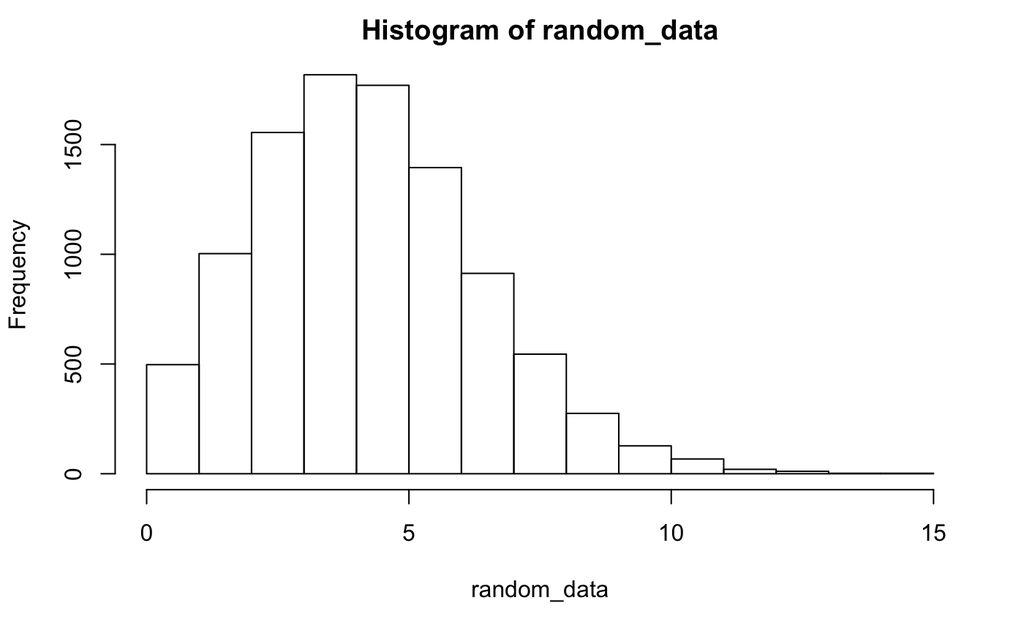

```r
random_data <- rpois(10000, 4.7)

hist(random_data)
```

16.)Using the “iris” dataset, write a for loop that calculates the mean Sepal length for each of the species of iris and prints the results.

```r
data(iris)
attach(iris)
summarized_iris <- NA
for (Species in c("setos", "versicolor", "virginica"))

{
summarised_iris <-iris %>% summarise(mean=mean(Sepal.Length))
  }

print(summarised_iris)
```

| mean |
| --- |
| 5.843333 |

```r
detach(iris)
```

17.) Using the “mtcars” dataset make a scatter plot of mpg vs. disp, include a regression line fit with a linear regression model or a loess smooth regression, make the color of the points different for each different number of cylinders in the engine.

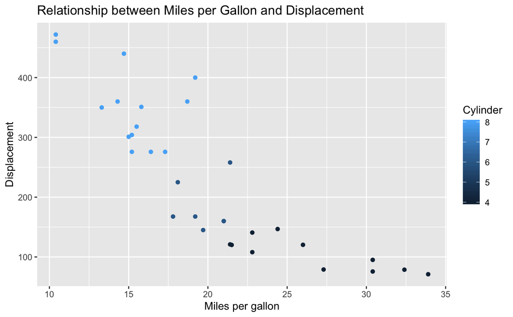

```r
data(mtcars)
ggplot(mtcars, aes(x= mpg, y= disp, color=cyl)) +
  geom_point() + labs(title="Relationship between Miles per Gallon and Displacement", x= "Miles per gallon", y="Displacement", color="Cylinder")
```

18.) Write a function to convert a vector of continuous data into its Z-scores (standard normal deviates). The formula for a Z-score is (x−μ)/σ where x is the vector of data, μ is the mean of x and σ is the standard deviation of x. Use the function to calculate the Z-scores for this vector {-4.89, -1.93, -1.11, 3.94, 0.46, -3.85, -0.20, 6.04, 9.36, 7.26, 4.88, 13.45, -2.93, 6.39, -16.22, -3.24, 6.86, 11.87, 1.81, -2.54}.

```r
data <- c(-4.89, -1.93, -1.11, 3.94, 0.46, -3.85, -0.20, 6.04, 9.36, 7.26, 4.88, 13.45, -2.93, 6.39, -16.22, -3.24, 6.86, 11.87, 1.81, -2.54)

z_scores<-(data-mean(data))/sd(data)

Q_18<-rbind(data,z_scores)

head(Q_18)
```

```
               [,1]       [,2]       [,3]      [,4]       [,5]       [,6]     [,7]      [,8]
data     -4.8900000 -1.9300000 -1.1100000 3.9400000  0.4600000 -3.8500000 -0.20000 6.0400000
z_scores -0.9682991 -0.5379762 -0.4187652 0.3154005 -0.1905196 -0.8171046 -0.28647 0.6206971
             [,9]     [,10]    [,11]     [,12]      [,13]     [,14]      [,15]      [,16]     [,17]
data     9.360000 7.2600000 4.880000 13.450000 -2.9300000 6.3900000 -16.220000 -3.2400000 6.8600000
z_scores 1.103356 0.7980599 0.452057  1.697958 -0.6833556 0.6715798  -2.615447 -0.7284232 0.7399081
             [,18]       [,19]      [,20]
data     11.870000 1.810000000 -2.5400000
z_scores  1.468259 0.005742484 -0.6266576
```

The values, along with their z-scores, are visible above.

This is the end of the final examination.

Thank you for the class, Ryan Herrschaft.